# E Commerce

Goutham Polamreddy

28 March 2020

# Introduction

### Problem Statement

The Objective of the project is to provide product recommendations based on the text analysis of Customer reviews.

### Need for the Study

The online marketing space is in constant shift as new technologies, services, and marketing tactics gain popularity and become the new standard. Online store owners are one of the many different segments affected by these constant evolutions. In order for these business owners to survive and thrive, they need to be able to make better decisions faster. This is where web analytics comes into play.

This is a Women’s Clothing E-Commerce dataset revolving around the reviews written by customers. Its nine supportive features offer a great environment to parse out the text through its multiple dimensions.

### Business Opportunity

- Help Business understand customer behaviour
- Contribute in increasing revenue by suggesting better products to customers.
- Support Business in Customer retention by providing relevant suggestions to customers.

# Data Report

**Data Collection:** This data is collected from reviews that customers provided for different products on a E Commerce website.

A quick glance at data below

```
##       Age       Rating    Recommended.IND Positive.Feedback.Count
##  Min.   :18.0   1:  842   0: 4172         0      :11176
##  1st Qu.:34.0   2: 1565   1:19314         1      : 4043
##  Median :41.0   3: 2871                   2      : 2193
##  Mean   :43.2   4: 5077                   3      : 1433
##  3rd Qu.:52.0   5:13131                   4      :  922
##  Max.   :99.0                             5      :  673
##                                           (Other): 3046
##         Division.Name   Department.Name     Class.Name
##                :   14           :   14   Dresses :6319
##  General       :13850   Bottoms : 3799   Knits   :4843
##  General Petite: 8120   Dresses : 6319   Blouses :3097
##  Initmates     : 1502   Intimate: 1735   Sweaters:1428
##                         Jackets : 1032   Pants   :1388
##                         Tops    :10468   Jeans   :1147
##                         Trend   :  119   (Other) :5264
```

Apart from the columns above there are two more variables namely **Title** and **Review Text** which holds title and content for the review respectively.

Different Attributes have below meanings:

This dataset includes 23486 rows and 10 feature variables. Each row corresponds to a customer review, and includes the variables:

**Clothing ID**: Integer Categorical variable that refers to the specific piece being reviewed.

**Age**: Positive Integer variable of the reviewers age.

**Title**: String variable for the title of the review.

**Review Text**: String variable for the review body.

**Rating**: Positive Ordinal Integer variable for the product score granted by the customer from 1 Worst, to 5 Best.

**Recommended IND**: Binary variable stating where the customer recommends the product where 1 is recommended, 0 is not recommended.

**Positive Feedback Count**: Positive Integer documenting the number of other customers who found this review positive.

**Division Name**: Categorical name of the product high level division.

**Department Name**: Categorical name of the product department name.

**Class Name**: Categorical name of the product class name.

# Exploratory Data Analysis

### Univariate Analysis

Let’s look at the distribution of Age of customers who reviewed the product.

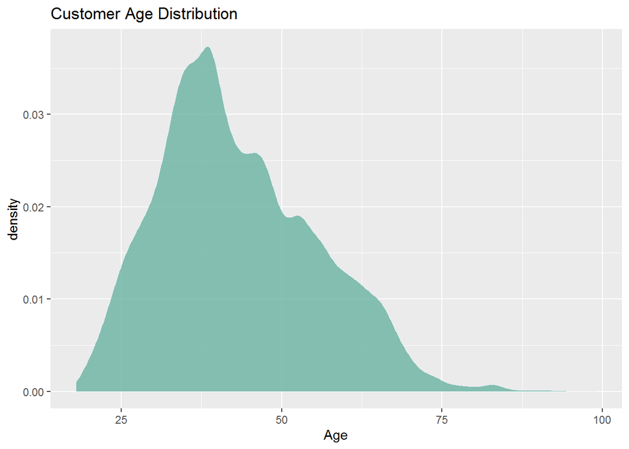

From the graph above, a majority of customers are between ages 30 and 50

Now, looking at the count of different clothing available

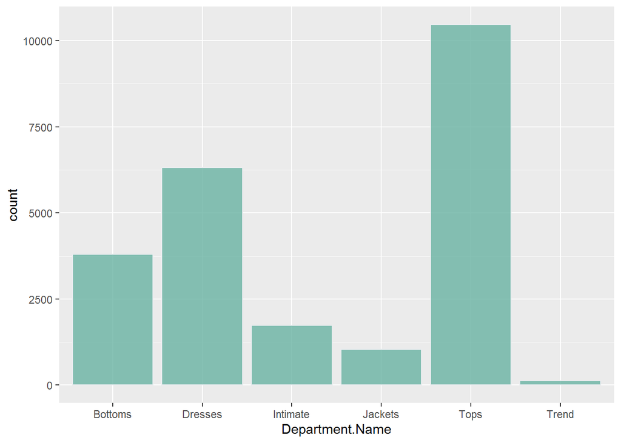

Moving on to analysing text columns. Analysing what the reviews talks about majorly helps to gain few insights into the nature of the data.

## Missing Value Treatment

Looking at the empty values in both columns( False= empty, True= Non empty)

```
##
##         FALSE  TRUE
##   FALSE   844  2966
##   TRUE      1 19675
```

The summary below of other variables where the text columns are both empty.

```
##       Age        Rating  Recommended.IND Positive.Feedback.Count
##  Min.   :20.00   1: 21   0: 71           0      :844
##  1st Qu.:34.00   2: 16   1:773           1      :  0
##  Median :39.00   3: 48                   2      :  0
##  Mean   :41.02   4:169                   3      :  0
##  3rd Qu.:47.00   5:590                   4      :  0
##  Max.   :91.00                           5      :  0
##                                          (Other):  0
##         Division.Name Department.Name    Class.Name
##                :  1           :  1    Knits   :217
##  General       :484   Bottoms :137    Dresses :173
##  General Petite:283   Dresses :173    Blouses :114
##  Initmates     : 76   Intimate: 82    Sweaters: 48
##                       Jackets : 30    Jeans   : 43
##                       Tops    :420    Skirts  : 42
##                       Trend   :  1    (Other) :207
```

- Positive feedback count of these rows is all 0, so removing these rows in further analysis.
- Also, removing the 14 empty rows from Division Name and Department Name

Summary of data after cleaning of empty values

```
##       Age        Rating    Recommended.IND Positive.Feedback.Count
##  Min.   :18.00   1:  821   0: 4101         0      :10322
##  1st Qu.:34.00   2: 1549   1:18528         1      : 4041
##  Median :41.00   3: 2823                   2      : 2193
##  Mean   :43.28   4: 4908                   3      : 1433
##  3rd Qu.:52.00   5:12528                   4      :  922
##  Max.   :99.00                             5      :  672
##                                            (Other): 3046
##         Division.Name   Department.Name     Class.Name
##                :    0           :    0   Dresses :6146
##  General       :13366   Bottoms : 3662   Knits   :4626
##  General Petite: 7837   Dresses : 6146   Blouses :2983
##  Initmates     : 1426   Intimate: 1653   Sweaters:1380
##                         Jackets : 1002   Pants   :1350
##                         Tops    :10048   Jeans   :1104
##                         Trend   :  118   (Other) :5040
```

### Creation of New Variables

Since there are missing values in either of Review text or Title, concatenate them both. This helps in doing text analysis on single column.

Variables in analysis after concatenation.

```
##  [1] "X"                       "Clothing.ID"
##  [3] "Age"                     "Review.Text"
##  [5] "Rating"                  "Recommended.IND"
##  [7] "Positive.Feedback.Count" "Division.Name"
##  [9] "Department.Name"         "Class.Name"
```

### Removing unwanted variables

Removing first two columns, which are IDs and doesn’t add much to the analysis.

Final variables for analysis.

```
## [1] "Age"                     "Review.Text"
## [3] "Rating"                  "Recommended.IND"
## [5] "Positive.Feedback.Count" "Division.Name"
## [7] "Department.Name"         "Class.Name"
```

### Outliers

No outliers considered in this Analysis

### Univariate analysis contd.

Analysis of word frequencies in the Review text is done below

Following analysis went into, while doing the analysis:

1. Words are converted to lowercase.
2. Punctuation is removed from the content.
3. Stop words are removed.
4. Stemming is done.

### Sentiment Analysis

We created a new sentiment which describes whether the review is positive or negative.

Below is plot of word frequency plot with both positive and negative words.

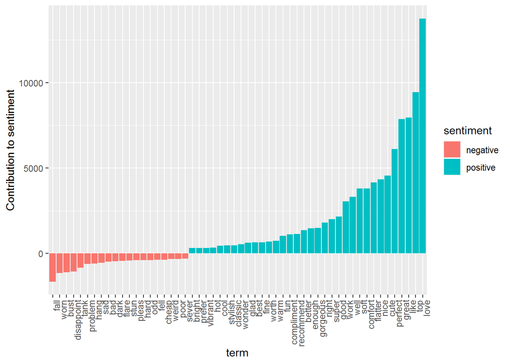

And word cloud below

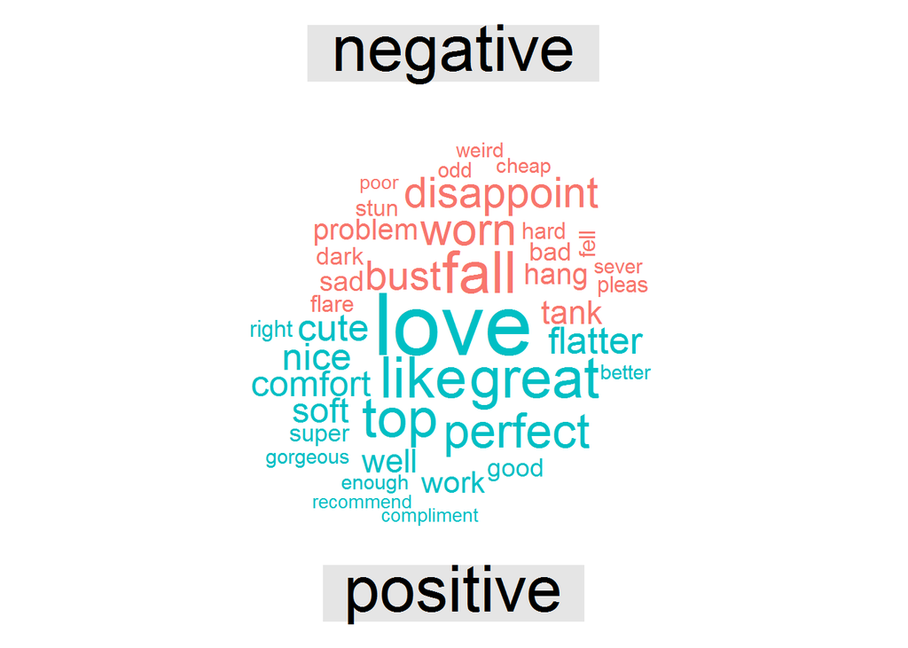

### Bivariate Analysis

Now looking at the how each variable varies with recommendation Ind

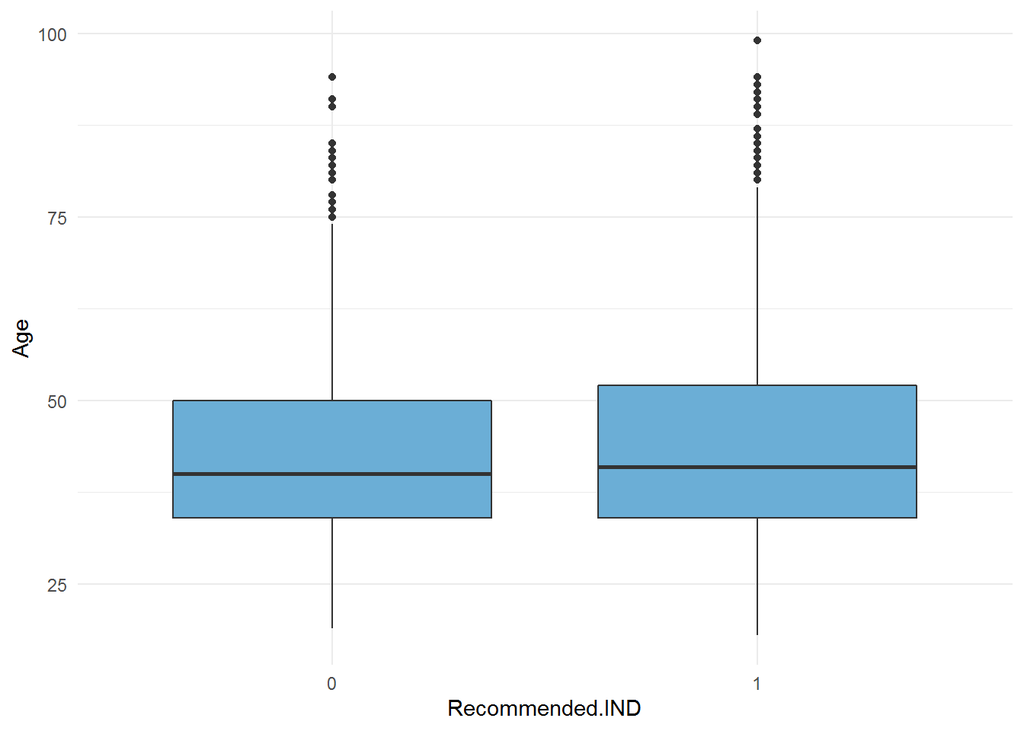

There is no significant difference in people Ages who recommended and not recommended a product

Next to positive feedback count vs recommendations

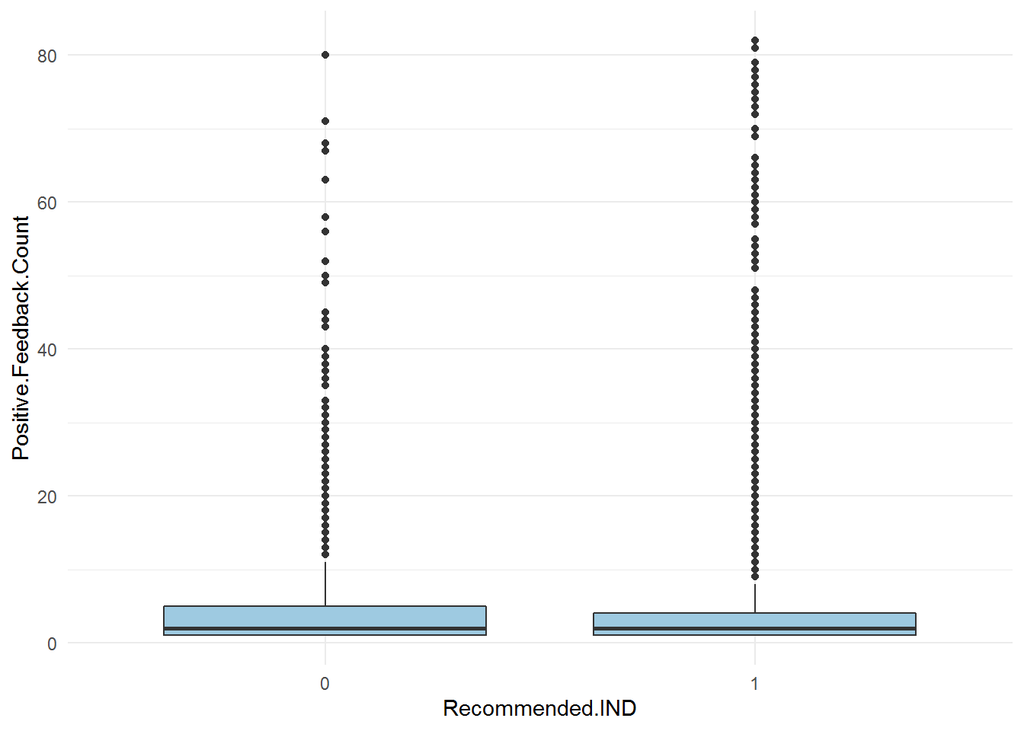

From the graph above, there are users who found both reviews where the product is recommended/not recommemended helpful.